# Day 19

## Review

#### Confidence Intervals for Proportions

**Point estimate for population proportions**

$$\hat{p}$$

**MOE (Margin of Error)**

$$z_{\alpha/2} \sqrt{\frac{\hat{p}(1 - \hat{p})}{n}}$$

**CLT for Proportions**

$$n\hat{p} \geq 10 \quad \text{and} \quad n(1 - \hat{p}) \geq 10$$

**CI for population proportions**

$$\hat{p} \pm z_{\alpha/2} \sqrt{\frac{\hat{p}(1 - \hat{p})}{n}} \quad \text{(Margin of Error)}$$

> **Steps for computing any confidence interval**
1. Find your point estimate
2. Determine your confidence level
3. Compute the margin of error
4. Construct the confidence interval via $\text{PE} \pm \text{MOE}$
5. Handle any interpretation steps by asking what the original research question was

> **The general method for all word problems**
1. What do I have?

> What relevant variables/information does the problem provide me outright?
2. What am I looking for?

> What is the problem asking me to provide as a final answer?
3. What tools do I have to find what I’m looking for?

> What equations do I know that have the final answer as a component of them?
4. What do I need to use the tools I have?

> Of the relevant variables/information that I have, which ones fit into the equations I’m looking at? Am I missing any information? Do I have excess information?
5. Does it all make sense?

> Does my final answer match the context of the original problem? If not, what would it need to make it make sense?

Put in practice:

> The daily sales of a local coffee shop are normally distributed with a population mean of $\mu = 300$ dollars and a standard deviation of $\sigma = 75$ dollars. If a random sample of $n = 49$ days is taken:
- What is the probability that we will observe a sample mean over $312$?

*What do I have?*

- $\mu=300$ dollars
- $\sigma=75$ dollars
- $n=49$ days
- Population **is** normally distributed

*What am I looking for?*

$$P(\bar{x}>312)$$

*What tools do I have to find what I’m looking for?*

- $z$-score formula:

$$P(X>x)=P\left(Z>{x-\mu \over \sigma}\right)=P(Z>z)$$

- $z$-table
- Empirical rule

*What do I need to use the tools I have?*

- $x$ or some single value
- $\mu$ or some mean
- $\sigma$ or some standard deviation
- Normally distributed data

**These all fit very well into our z-score formula**

$$P(X>312)=P\left(Z>{312-300 \over 75}\right)=P(Z>0.16)$$

$$P(Z>0.16)=1-P(Z<0.16)=0.436$$

*Does it all make sense?*

We know that the data is **normally distributed** so:

- $68\%$ of the data should be within $1$ standard deviation

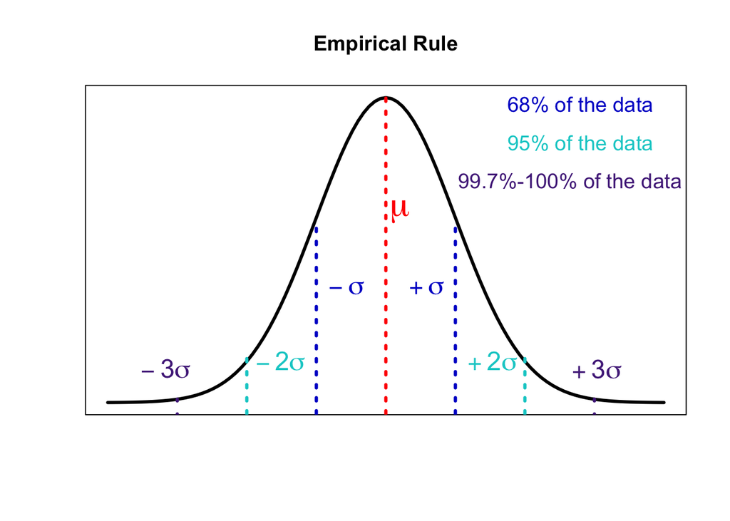

> Let’s think about this

$$\approx 100\% \text{ data}\Rightarrow \pm3 \ \sigma$$

$$\approx 50\% \text{ data} \Rightarrow + \text{ OR} - 3 \ \sigma$$

$$312 = 0.16 \ \sigma$$

> If we exclude a pretty central but small chunk of our strictly $+\sigma$ population, we should expect our value to be something a little less than $50\%$

#### Hypothesis Testing

In hypothesis testing, there are two competing statements about population parameters:

$$H_0\equiv \text{null hypothesis} \quad \text{vs} \quad H_1 \equiv \text{alternate hypothesis}$$

The null hypothesis, $H_0$, states that the parameter is **equal to** a specific value

$$H_0 : \mu = 35$$

The alternate hypothesis, $H_1$, states that the value of the parameter **differs** from the value specified by the null hypothesis

$$H_1 : \mu < 35$$

$$H_1 : \mu > 35$$

$$H_1 : \mu \neq 35$$

**There are three types of alternate hypothesis**

- Consider $H_0 : \mu = 35$
1. $H_1 : \mu < 35$ $\Rightarrow$ called **left-tailed** alternate hypothesis
2. $H_1 : \mu > 35$ $\Rightarrow$ called **right-tailed** alternate hypothesis
3. $H_1 : \mu \neq 35$ $\Rightarrow$ called **two-tailed** alternate hypothesis

Left-tailed and right-tailed hypotheses are called **one-tailed** hypotheses

A null hypothesis is generally thought of as a **default state of nature** (e.g. existing knowledge)

An alternate hypothesis, on the other hand, **contradicts** the default state (e.g. new knowledge)

In most cases, whatever **we wish to establish** is placed in the **alternate hypothesis**

After developing $H_0$ and $H_1$, we collect a set of data

- Based on the data, we construct a test statistic to reach one of the following decisions:
  - **Reject** $H_0$
  - **Fail** to reject $H_0$

If we **reject** $H_0$

- We conclude that $H_1$ is **true**

If we **fail to reject** $H_0$

- We conclude that the data **do not provide enough evidence to reject** $H_0$

**Type I error**: $H_0$ is true in reality, but we reject $H_0$

**Type II error**: $H_1$ is true in reality, but we do not reject $H_0$

$$\begin{array}{|c|c|c|}
\hline
\text{Decision} & H_0 \ \text{True} & H_0 \ \text{False} \\
\hline
\text{Reject} \ H_0 & \text{Type I error} & \text{Correct decision} \\
\hline
\text{Don’t reject} \ H_0 & \text{Correct decision} & \text{Type II error} \\
\hline
\end{array}$$

The probability of having the Type I error is denoted by $\alpha$

The probability of having the Type II error is denoted by $\beta$

**Questions?**

**Plan for today:**

1. Review practice content for Exam 2
2. Q/A on Exam 2 material

> Please refer to the Exam 2 Review packet